# 5. Divide and Conquer I

5. Divide and Conquer I

WU Xiaokun 吴晓堃

xkun.wu [at] gmail

2021/10/29

## Divide-and-conquer paradigm

**Divide-and-conquer**.

- Divide up problem into *several* sub-problems (of the same kind).
- Solve (conquer) each subproblem recursively.
- Combine solutions to sub-problems into overall solution.

**Most common usage**.

- Divide problem of size n into *two* sub-problems of size $n / 2$.
- Solve (conquer) two sub-problems recursively.
- Combine two solutions into overall solution.

**Benefit**. Closest Pair Problem:

- Brute force: $\Theta(n^2)$.
- Divide-and-conquer: $O(n \log n)$.

# Mergesort

## Sorting problem

**Problem**. Given a list $L$ of $n$ elements from a totally ordered universe, rearrange them in ascending order.

## Sorting applications

**Obvious applications**.

- Organize an MP3 library.
- Display Google PageRank results.
- List RSS news items in reverse chronological order.

**Some problems become easier once elements are sorted**.

- Identify statistical outliers.
- Binary search in a database.
- Remove duplicates in a mailing list.

**Non-obvious applications**.

- Convex hull.
- Closest pair of points.
- Interval scheduling / interval partitioning.
- Scheduling to minimize maximum lateness.
- Minimum spanning trees (Kruskal’s algorithm).

## Mergesort

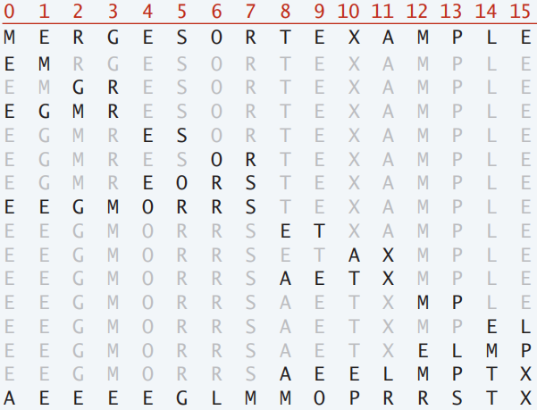

## Merging

**Goal**. Combine two sorted lists $A$ and $B$ into a sorted whole $C$.

- Scan $A$ and $B$ from left to right.
- Compare $a_i$ and $b_j$.
- If $a_i \le b_j$, append $a_i$ to $C$ (no larger than any remaining element in $B$).
- If $a_i > b_j$, append $b_j$ to $C$ (smaller than every remaining element in A).

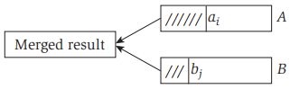

## Mergesort implementation

**Input**. List $L$ of $n$ elements from a totally ordered universe.  
**Output**. The $n$ elements in ascending order.

1. IF (list $L$ has one element) RETURN $L$;
2. Divide the list into two halves $A$ and $B$;
3. $A$ = `MERGE-SORT`($A$): $T(n/2)$;
4. $B$ = `MERGE-SORT`($B$): $T(n/2)$;
5. $L$ = `MERGE`($A$, $B$): $\Theta(n)$;
6. RETURN $L$;

## Recurrence relation: divide-by-2

**Def**. $T(n)$ = max number of compares to mergesort a list of length $n$.

**Recurrence**.

$$T(n) \le \left\{ \begin{array}{lcl}
0 & \text{if} & n = 1 \\
T(\lfloor n/2 \rfloor) + T(\lceil n/2 \rceil) + cn & \text{if} &
n > 1 \\
\end{array}\right.$$

- Base case: $T(2) \le 2c$ is a constant; $cn = O(n)$.

**Solution**. $T(n)$ is $O(n \log_2 n)$.

**Assorted proofs**. We describe several ways to solve this recurrence.

- Initially, assume $n$ is a power of $2$ and replace $\le$ with $=$.
- Asymptotic bounds are not affected by ignoring floors/ceilings.

## Recurrence: unrolling tree

**Proposition**. If $T(n)$ satisfies the following recurrence, then $T(n) = cn \log_2 n$.

$$T(n) = \left\{ \begin{array}{lcl}
0 & \text{if} & n = 1 \\
2T(n/2) + cn & \text{if} & n > 1 \\
\end{array}\right.$$

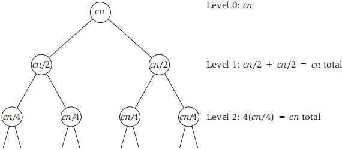

**Pf**. [ by identifying a pattern ]  
$cn$ per level, $\log_2 n$ levels.

## Recurrence: substitution

**Proposition**. If $T(n)$ satisfies the following recurrence, then $T(n) = cn \log_2 n$.

$$T(n) = \left\{ \begin{array}{lcl}
0 & \text{if} & n = 1 \\
2T(n/2) + cn & \text{if} & n > 1 \\
\end{array}\right.$$

**Pf**. [ by induction on n ]

- $T(1) = 0 = cn \log_2 n$.
  - assume $T(n/2) = c(n/2) \log_2 (n/2)$.

$$\begin{aligned}
T(n) & = 2T(n/2) + cn \\
& = 2c(n/2) \log_2(n/2) + cn \\
& = cn[(\log_2 n) − 1]+ cn \\
& = (cn \log_2 n) − cn + cn \\
& = cn \log_2 n \\
\end{aligned}$$

## Recurrence: partial substitution

**Proposition**. If $T(n)$ satisfies the following recurrence, then $T(n) = cn \log_2 n$.

$$T(n) = \left\{ \begin{array}{lcl}
0 & \text{if} & n = 1 \\
2T(n/2) + cn & \text{if} & n > 1 \\
\end{array}\right.$$

**Pf**. [ guess $T(n) = kn \log_b n$ ]

- $T(n) = 2k(n/2) \log_b (n/2) + cn$.
  - $b=2$ looks good for halving.
  - $T(n) = (kn \log_2 n) − kn + cn$.
    - $k=c$ makes the guess right.

## Quiz: divide-by-2 recurrence

Which is the exact solution of the following recurrence?

$$T(n) = \left\{ \begin{array}{lcl}
0 & \text{if} & n = 1 \\
T(\lfloor n/2 \rfloor) + T(\lceil n/2 \rceil) + n - 1 & \text{if}
& n > 1 \\
\end{array}\right.$$

**A**. $T(n) = n \lfloor \log_2 n \rfloor$  
**B**. $T(n) = n \lceil \log_2 n \rceil$  
**C**. $T(n) = n \lfloor \log_2 n \rfloor + 2^{\lfloor \log_2 n \rfloor} − 1$  
**D**. $T(n) = n \lceil \log_2 n \rceil − 2^{\lceil \log_2 n \rceil} + 1$  
**E**. Not even Knuth knows.

$$\begin{aligned}
T(2n) & = 2T(n) + 2n - 1 \\
(D) & = 2n \lceil \log_2 n \rceil − 2^{\lceil \log_2 n \rceil + 1} +
2 + 2n - 1 \\
& = 2n \lceil \log_2 n \rceil − 2^{\lceil \log_2 n \rceil + 1} + 2n
+ 1 \\
\end{aligned}$$

$$\begin{aligned}
T(2n) & = 2n \lceil \log_2 2n \rceil − 2^{\lceil \log_2 2n \rceil} +
1 \\
& = 2n \lceil \log_2 n + 1 \rceil - 2^{\lceil \log_2 n + 1\rceil} +
1 \\
& = 2n (\lceil \log_2 n \rceil + 1) - 2^{\lceil \log_2 n \rceil + 1}
+ 1 \\
& = 2n \lceil \log_2 n \rceil - 2^{\lceil \log_2 n \rceil + 1} + 2n
+ 1 \\
\end{aligned}$$

## Mergesort: analysis

**Proposition**. If $T(n)$ satisfies the following recurrence, then $T(n) \le n \lceil \log_2 n \rceil$.

$$T(n) \le \left\{ \begin{array}{lcl}
0 & \text{if} & n = 1 \\
T(\lfloor n/2 \rfloor) + T(\lceil n/2 \rceil) + n & \text{if} &
n > 1 \\
\end{array}\right.$$

**Pf**. [ by strong induction on n ]  
Induction step: assume true for $1, 2, \ldots, n – 1$.  
Let $n_1 = \lfloor n / 2 \rfloor$ and $n_2 = \lceil n / 2 \rceil$: note that $n = n_1 + n_2$.

$$\begin{aligned}
T(n) & \le T(n_1) + T(n_2) + n \\
& \le n_1 \lceil \log_2 n_1 \rceil + n_2 \lceil \log_2 n_2 \rceil +
n \\
& \le n_1 \lceil \log_2 n_2 \rceil + n_2 \lceil \log_2 n_2 \rceil +
n \\
& = n \lceil \log_2 n_2 \rceil + n \\
(\ast) & \le n (\lceil \log_2 n \rceil – 1) + n \\
& = n \lceil \log_2 n \rceil \\
\end{aligned}$$

$$\begin{aligned}
n_2 & = \lceil n/2 \rceil \\
& \le \lceil 2^{\lceil \log_2 n \rceil} /2 \rceil \\
& = 2^{\lceil \log_2 n \rceil} /2 \\
& \Downarrow \\
(\ast) \log_2 n_2 & \le \lceil \log_2 n \rceil - 1 \\
\end{aligned}$$

## Digression: sorting lower bound

**Challenge**. How to prove a lower bound for *all* conceivable algorithms?

**Model of computation**. Comparison trees.

- Can access the elements only through pairwise comparisons.
- All other operations (control, data movement, etc.) are free.

**Cost model**. Number of compares.

**Q**. Realistic model?  
**A1**. Yes. Java, Python, C++, etc.  
**A2**. Yes. Mergesort, insertion sort, quicksort, heapsort, etc.  
**A3**. No. Bucket sort, radix sorts, etc.

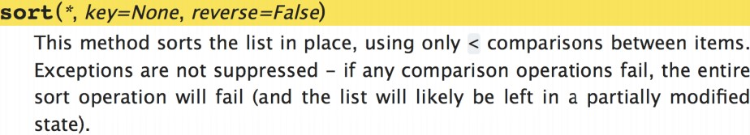

## Comparison tree (3 distinct keys)

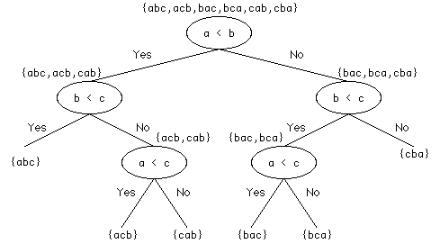

## Sorting lower bound

- Assume array consists of $n$ distinct values $a_1 .. a_n$.
- Worst-case number of compares = height $h$ of pruned comparison tree.
- Binary tree of height $h$ has $\le 2^h$ leaves.
- $n!$ different orderings $\Rightarrow n!$ reachable leaves.

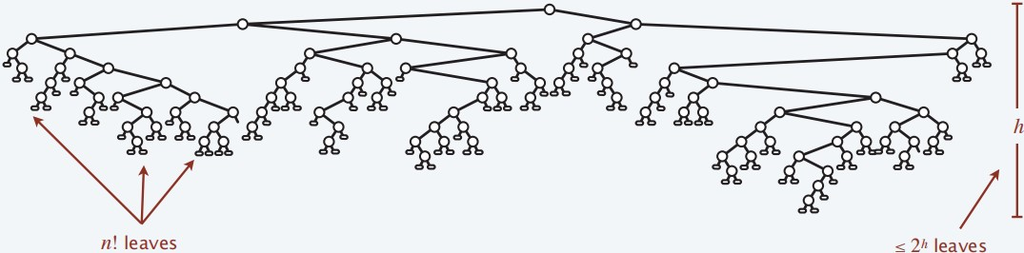

## Sorting lower bound (cont.)

- Assume array consists of $n$ distinct values $a_1 .. a_n$.
- Worst-case number of compares = height $h$ of pruned comparison tree.
- Binary tree of height $h$ has $\le 2^h$ leaves.
- $n!$ different orderings $\Rightarrow n!$ reachable leaves.

$$\begin{aligned}
2^h & \ge n! \\
\Rightarrow h & \ge \log_2 n! \\
(Stirling’s) & \ge n \log_2 n - n / \ln 2 \\
\end{aligned}$$

**Note**. Lower bound can be extended to include *randomized* algorithms.

# Further Recurrence Relations

## Recurrence Relations

More general formulation: recursively solve $q$ sub-problems of size $n/2$ each:

$$T(n) \le \left\{ \begin{array}{lcl}
0 & \text{if} & n = 1 \\
qT(n/2) + cn & \text{if} & n > 1 \\
\end{array}\right.$$

- Base case: $T(2) \le 2c$ is a constant; $cn = O(n)$.

$$T(n) \le qT(n/2) + cn$$

**Pf**. Geometric sum: $\sum_{j=0}^{\log_2 n - 1}(r)^j = \frac{r^{\log_2 n} - 1}{r - 1}$.

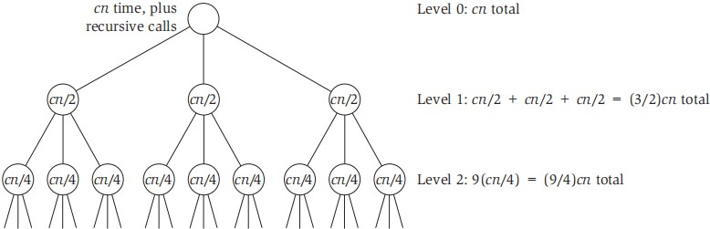

Especially, $O(n^{\log_2 3}) = O(n^{1.59})$, $O(n^{\log_2 4}) = O(n^2)$.

## Recurrence Relations: $q = 1$

**Proposition**. If $T(n)$ satisfies the following recurrence with $q = 1$, then $T(n) = O(n)$.

$$T(n) \le qT(n/2) + cn$$

**Pf**. Geometric sum: $\sum_{j=0}^{\log_2 n - 1}(\frac{1}{2^j}) = 2$.

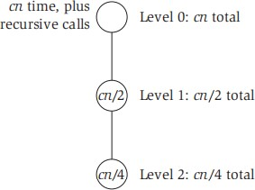

## Recurrence Relations: quadratic time

Special case: spending quadratic time for the initial division and final recombining.

$$T(n) \le \left\{ \begin{array}{lcl}
0 & \text{if} & n = 1 \\
2T(n/2) + cn^2 & \text{if} & n > 1 \\
\end{array}\right.$$

- Base case: $T(2) \le 4c$ is a constant; $cn^2 = O(n^2)$.

# Counting inversions

**Music recommendation**. Music site tries to match your preference with others.

- You rank $n$ songs.
- Music site consults database to find people with similar tastes.

**Similarity metric**: number of **inversions** between two rankings.

- My rank: $1, 2, \ldots, n$.
- Your rank: $a_1, a_2, \ldots, a_n$.
- Songs $i$ and $j$ are inverted if $i < j$, but $a_i > a_j$.

|  | A | B | C | D | E |
| --- | --- | --- | --- | --- | --- |
| me | 1 | 2 | 3 | 4 | 5 |
| you | 1 | 3 | 4 | 2 | 5 |

**Brute force**: check all $\Theta(n^2)$ pairs.

## Counting inversions: divide-and-conquer

- Divide: separate list into two halves $A$ and $B$.
- Conquer: recursively count inversions in each list.
- Combine: count inversions $(a, b)$ with $a \in A, b \in B$.
- Return sum of three counts.

| 1 | 5 | 4 | 8 | 10 | 2 | 6 | 9 | 3 | 7 |
| --- | --- | --- | --- | --- | --- | --- | --- | --- | --- |
| 1 | 5 | 4 | 8 | 10 |  |  |  |  |  |
| 2 | 6 | 9 | 3 | 7 |  |  |  |  |  |

**Output**. $1 + 3 + 13 = 17$.

## Counting inversions: how to combine?

**Q**. How to count inversions $(a, b)$ with $a \in A, b \in B$?  
**A**. Easy if A and B are sorted!

**Warmup algorithm**.

1. Sort $A$ and $B$
2. For each element $b_j \in B$:
   1. binary search $\argmin_i \{b_j < a_i\}$;

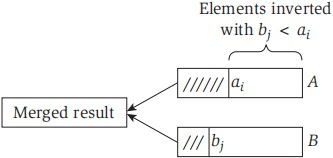

| 7 | 10 | 18 | 3 | 14 | 20 | 23 | 2 | 11 | 16 |
| --- | --- | --- | --- | --- | --- | --- | --- | --- | --- |
| 3 | 7 | 10 | 14 | 18 |  |  |  |  |  |
| 2 | 11 | 16 | 20 | 23 |  |  |  |  |  |

**Output**. $5 + 2 + 1 + 0 + 0 = 8$.

## Counting inversions: merge-and-count

Count inversions $(a, b)$ with $a \in A, b \in B$, assuming $A$ and $B$ are sorted.

Scan $A$ and $B$ from left to right:

- Compare $a_i$ and $b_j$.
  - If $a_i < b_j$, then $a_i$ is not inverted with *any* element left in $B$.
  - If $a_i > b_j$, then $b_j$ is inverted with *every* element left in $A$.
- Append smaller element to sorted list $C$.

| 7 | 10 | 18 | 3 | 14 | 20 | 23 | 2 | 11 | 16 |
| --- | --- | --- | --- | --- | --- | --- | --- | --- | --- |
| 3 | 7 | 10 | 14 | 18 |  |  |  |  |  |
|  |  |  | $a_i$ | 18 |  |  |  |  |  |
| 2 | 11 | 16 | 20 | 23 |  |  |  |  |  |
| 5 | 2 | $b_j$ | 20 | 23 |  |  |  |  |  |
| 2 | 3 | 7 | 10 | 11 |  |  |  |  |  |

## Counting inversions: algorithm

**Input**. List $L$.  
**Output**. Number of inversions in $L$ and $L$ in sorted order.

1. IF (list $L$ has one element) RETURN $(0, L)$;
2. Divide the list into two halves $A$ and $B$;
3. $(r_A, A)$ = `SORT-AND-COUNT`($A$): $T(n/2)$;
4. $(r_B, B)$ = `SORT-AND-COUNT`($B$): $T(n/2)$;
5. $(r_{AB}, L)$ = `MERGE-AND-COUNT`($A$, $B$): $\Theta(n)$;
6. RETURN $(r_A + r_B + r_{AB}, L)$;

## Counting inversions: analysis

**Proposition**. The sort-and-count algorithm counts the number of inversions in a permutation of size $n$ in $O(n \log n)$ time.  
**Pf**. The worst-case running time $T(n)$ satisfies the recurrence:

$$T(n) = \left\{ \begin{array}{lcl}
\Theta(1) & \text{if} & n = 1 \\
T(\lfloor n/2 \rfloor) + T(\lceil n/2 \rceil) + \Theta(n) &
\text{if} & n > 1 \\
\end{array}\right.$$

# Randomized quicksort

## 3-way partitioning

**Goal**. Given an array $A$ and pivot element $p$, partition array so that:

- Smaller elements in left sub-array $L$.
- Equal elements in middle sub-array $M$.
- Larger elements in right sub-array $R$.

| 7 | 6 | 12 | 3 | 11 | 8 | 9 | 1 | 4 | 10 | 2 |
| --- | --- | --- | --- | --- | --- | --- | --- | --- | --- | --- |
|  |  | L |  | **6** |  |  | R |  |  |  |
| 3 | 1 | 4 | 2 | **6** | 7 | 12 | 11 | 8 | 9 | 10 |

**Challenge**. $O(n)$ time and $O(1)$ space.

## Demo: 3-way partitioning

## Randomized quicksort: idea

- Pick a random pivot element $p \in A$.
- 3-way partition the array into $L$, $M$, and $R$.
- Recursively sort both $L$ and $R$.

|  | 7 | 6 | 12 | 3 | 11 | 8 | 9 | 1 | 4 | 10 | 2 |
| --- | --- | --- | --- | --- | --- | --- | --- | --- | --- | --- | --- |
| partition | 3 | 1 | 4 | 2 | **6** | 7 | 12 | 11 | 8 | 9 | 10 |
| sort L | 1 | 2 | 3 | 4 | **6** |  |  |  |  |  |  |
| sort R |  |  |  |  | **6** | 7 | 8 | 9 | 10 | 11 | 12 |
| sorted | 1 | 2 | 3 | 4 | **6** | 7 | 8 | 9 | 10 | 11 | 12 |

## Randomized quicksort: algorithm

**Input**. List $A$.  
**Output**. $A$ in sorted order.

1. IF (list $A$ has zero or one element) RETURN;
2. Pick pivot $p \in A$ uniformly at random;
3. $(L, M, R)$ = `PARTITION-3-WAY`($A, p$): $\Theta(n)$;
4. `RANDOMIZED-QUICKSORT`($L$): $T(i)$;
5. `RANDOMIZED-QUICKSORT`($R$): $T(n-i-1)$;

## Demo: Randomized quicksort

## Randomized quicksort: analysis

**Proposition**. The expected number of compares to quicksort an array of $n$ distinct elements $a_1 < a_2 < \ldots < a_n$ is $O(n \log n)$.  
**Pf**. Consider BST representation of pivot elements.

- $a_i$ and $a_j$ are compared once iff one is an ancestor of the other.
  - $a_3$ and $a_6$ are compared (when $a_3$ is pivot)
  - $a_2$ and $a_8$ are not compared (because $a_3$ partitions them)

## Quiz: Quicksort 1

Given an array of $n \ge 8$ distinct elements $a_1 < a_2 < \ldots < a_n$, what is the probability that $a_7$ and $a_8$ are compared during randomized quicksort?

**A**. 0  
**B**. 1 / n  
**C**. 2 / n  
**D**. 1

D: ancestry

## Quiz: Quicksort 1

Given an array of $n \ge 2$ distinct elements $a_1 < a_2 < \ldots < a_n$, what is the probability that $a_1$ and $a_n$ are compared during randomized quicksort?

**A**. 0  
**B**. 1 / n  
**C**. 2 / n  
**D**. 1

C: compared iff either is chosen as pivot before any of the other

## Randomized quicksort: analysis (cont. 1)

**Proposition**. The expected number of compares to quicksort an array of $n$ distinct elements $a_1 < a_2 < \ldots < a_n$ is $O(n \log n)$.  
**Pf**. Consider BST representation of pivot elements.

- $a_i$ and $a_j$ are compared once iff one is an ancestor of the other.
- Pr [ $a_i$ and $a_j$ are compared ] = $2 / ( j - i + 1)$, where $i < j$.
  - Pr[$a_2$ and $a_8$ compared] = $2/7$ compared if either $a_2$ or $a_8$ is chosen as pivot before any of $\{ a_3, a_4, a_5, a_6, a_7\}$

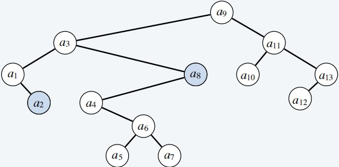

## Randomized quicksort: analysis (cont. 2)

**Proposition**. The expected number of compares to quicksort an array of $n$ distinct elements $a_1 < a_2 < \ldots < a_n$ is $O(n \log n)$.  
**Pf**. Consider BST representation of pivot elements.

- $a_i$ and $a_j$ are compared once iff one is an ancestor of the other.
- Pr [ $a_i$ and $a_j$ are compared ] = $2 / ( j - i + 1)$, where $i < j$.

Expected number of compares:

$$\begin{aligned}
\sum_{i=1}^n\sum_{j=i+1}^n \frac{2}{j-i+1} & = 2
\sum_{i=1}^n\sum_{j=2}^{n-i+1} \frac{1}{j} \\
& \le 2n \sum_{j=1}^{n} \frac{1}{j} \\
(harmonic) & \le 2n (\ln n + 1) \\
\end{aligned}$$

**Remark**. Number of compares only decreases on equal elements.

# Closest pair of points

## Closest Pair Problem

**Closest Pair Problem**. Given $n$ points in the plane, find a pair of points with the smallest Euclidean distance between them.

**Fundamental geometric primitive**.

- Graphics, computer vision, geographic information systems, molecular modeling, air traffic control.
- Special case of nearest neighbor, Euclidean MST, Voronoi.

**Brute force**. Check all pairs with (n^2) distance calculations.

- **1D version**. Easy $O(n \log n)$ algorithm if points are on a line.
- **Non-degeneracy assumption**. No two points have the same $x$-coordinate.

## Closest Pair: first attempt

**Sorting solution**.

- Sort by $x$-coordinate and consider nearby points.
- Sort by $y$-coordinate and consider nearby points.

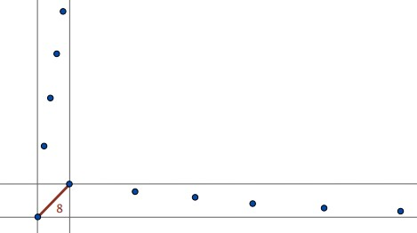

## Closest Pair: second attempt

**Divide**. Subdivide region into $4$ quadrants.

**Obstacle**. Impossible to ensure $n / 4$ points in each piece.

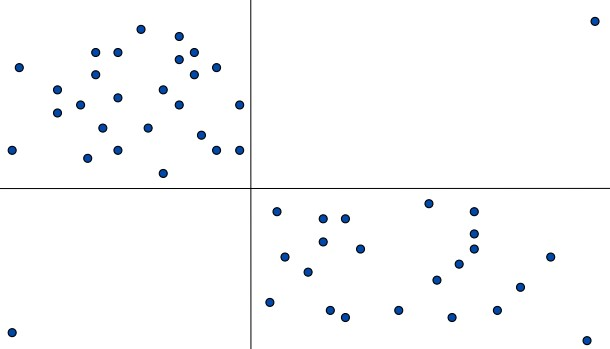

## Closest Pair: divide-and-conquer

- **Divide**: draw vertical line $L$ so that $n / 2$ points on each side.
- **Conquer**: find closest pair in each side recursively.
- **Combine**: find closest pair with one point in each side.
  - looks like $\Theta(n^2)$?
- Return best of $3$ solutions.

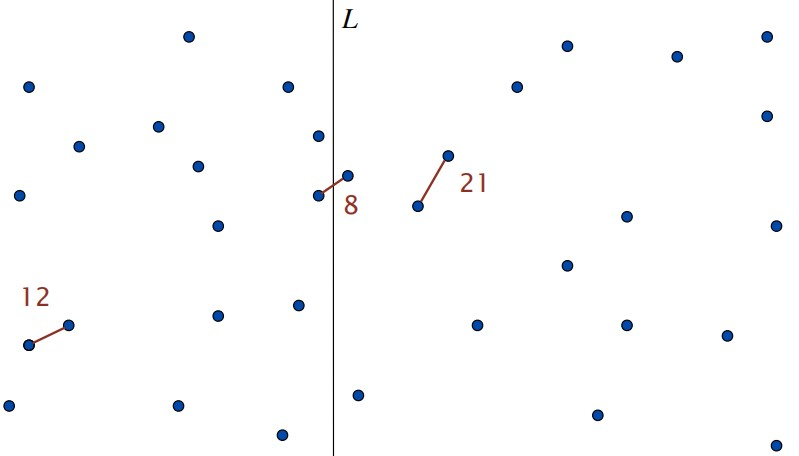

## Closest pair: one point in each side?

Find closest pair with one point in each side, assuming that distance $< \delta$.

**Observation**: suffices to consider only those points within $\delta$ of line $L$.

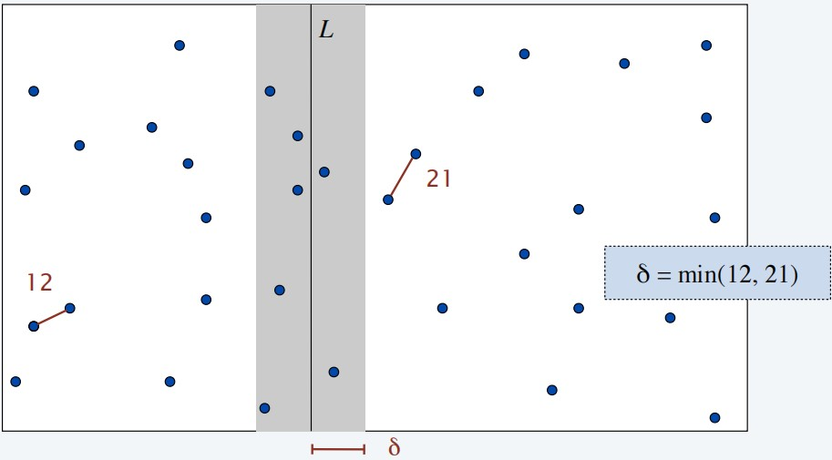

## Closest pair: one point in each side? (cont.)

Find closest pair with one point in each side, assuming that distance $< \delta$.

**Observation**: suffices to consider only those points within $\delta$ of line $L$.

- Sort points in 2 $\delta$-strip by their $y$-coordinate.
- Check distances of only those points within $7$ positions in sorted list!
  - But, why?

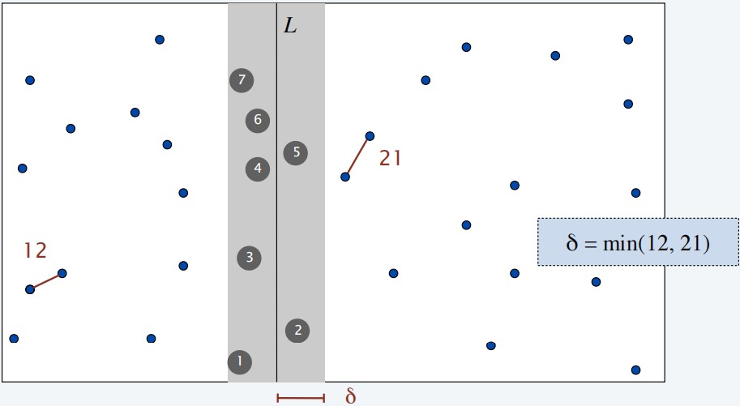

## Closest pair: one point in each side

**Def**. Let $s_i$ be the point in the 2 $\delta$-strip, with the $i^{th}$ smallest $y$-coordinate.

**Claim**. If $|j – i| > 7$, then the distance between $s_i$ and $s_j$ is at least $\delta$.  
**Pf**.

Consider the $2\delta$-by-$\delta$ rectangle $R$ in strip whose min $y$-coordinate is $y$-coordinate of $s_i$.

- Distance between $s_i$ and any point $s_j$ outside $R$ is $\ge \delta$.
- Subdivide R into 8 squares.
  - At most 1 point per square.
    - otherwise, $\delta * \sqrt{2}/2 < \delta$.
  - At most 7 other points can be in R.

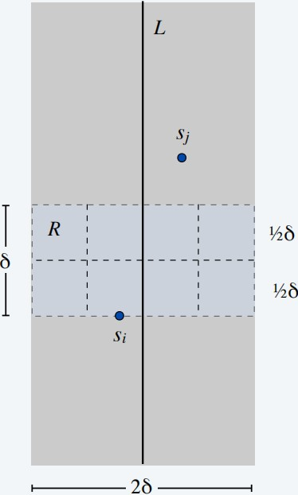

## Closest pair: algorithm

**Input**. $n$ points $P = p_1, p_2, \ldots, p_n$.  
**Output**. distance $\delta$.

1. Compute vertical line $L$ such that half the points are on each side of the line: $O(n)$;
2. $\delta_1$ = `CLOSEST-PAIR`(points in left half): $T(n/2)$;
3. $\delta_2$ = `CLOSEST-PAIR`(points in right half): $T(n/2)$;
4. $\delta = \min \{ \delta_1 , \delta_2 \}$;
5. Delete all points further than $\delta$ from line $L$: $O(n)$;
6. Sort remaining points by $y$-coordinate: $O(n \log n)$;
7. Scan points in $y$-order and compare distance between each point and next 7 neighbors. If any of these distances is less than $\delta$, update $\delta$.
8. RETURN $\delta$.

## Quiz: Closest pair

What is the solution to the following recurrence?

$$T(n) = \left\{ \begin{array}{lcl}
\Theta(1) & \text{if} & n = 1 \\
T(\lfloor n/2 \rfloor) + T(\lceil n/2 \rceil) + \Theta(n \log n) &
\text{if} & n > 1 \\
\end{array}\right.$$

**A**. $T(n) = \Theta(n)$.  
**B**. $T(n) = \Theta(n \log n)$.  
**C**. $T(n) = \Theta(n \log^2 n)$.  
**D**. $T(n) = \Theta(n^2)$.

C

## Closest pair: Refined algorithm

**Q**. How to improve to $O(n \log n)$ ?  
**A**. Don’t sort points in strip from scratch each time.

- Each recursive call returns two lists: all points sorted by $x$-coordinate, and all points sorted by $y$-coordinate.
- Sort by *merging* two pre-sorted lists.

**Theorem**. [Shamos 1975] The divide-and-conquer algorithm for finding a closest pair of points in the plane can be implemented in $O(n \log n)$ time.  
**Pf**.

$$T(n) = \left\{ \begin{array}{lcl}
\Theta(1) & \text{if} & n = 1 \\
T(\lfloor n/2 \rfloor) + T(\lceil n/2 \rceil) + \Theta(n) &
\text{if} & n > 1 \\
\end{array}\right.$$

## Closest pair: Computational complexity

**Theorem**. [Ben-Or 1983, Yao 1989] In quadratic decision tree model, any algorithm for closest pair (even in 1D) requires $\Omega(n \log n)$ quadratic tests.

**Theorem**. [Rabin 1976] There exists an algorithm to find the closest pair of points in the plane whose *expected* running time is $O(n)$.

## Digression: computational geometry

Ingenious divide-and-conquer algorithms for core geometric problems.

| problem | brute | clever |
| --- | --- | --- |
| closest pair | $O(n^2)$ | $O(n \log n)$ |
| farthest pair | $O(n^2)$ | $O(n \log n)$ |
| convex hull | $O(n^2)$ | $O(n \log n)$ |
| Delaunay/Voronoi | $O(n^4)$ | $O(n \log n)$ |
| Euclidean MST | $O(n^2)$ | $O(n \log n)$ |